# OLA Driver Churn Prediction

## SMOTE

```python
sm = SMOTE(random_state=42, k_neighbors=5)
X_train_sm, y_train_sm = sm.fit_resample(X_train, y_train)
```

## Reusable function for model evalution

```python
def eval(yt, yp):
    print(f"Recall score: {round(recall_score(yt, yp), 3)}")
    print(f"Precision score: {round(precision_score(yt, yp), 3)}")
    print(f"F1 score: {round(f1_score(yt, yp), 3)}")
    print(f"ROC_AUC score: {round(roc_auc_score(yt, yp), 3)}")
    print(f"Accuracy: {round(accuracy_score(yt, yp), 3)}")
    print(f"Classification report: {classification_report(yt, yp)}")
    print(f"Confusion Matrix: {confusion_matrix (yt, yp)}")
```

## Training ML models

```python
def make_pipeline(model, scale=False):
    steps = []
    if scale:
        steps.append(('scaler', StandardScaler()))
    steps.append(('model', model))
    return Pipeline(steps=steps)

models = {
    "Logistic Regression": make_pipeline(
        LogisticRegression(max_iter=500, class_weight='balanced'), scale=True
    ),
    "SVM (RBF)": make_pipeline(
        SVC(kernel='rbf', probability=True, class_weight='balanced'), scale=True
    ),
    "Decision Tree": make_pipeline(
        DecisionTreeClassifier(
            max_depth=6, min_samples_leaf=50, class_weight='balanced', random_state=42
        ), scale=False
    ),
    "Random Forest": make_pipeline(
        RandomForestClassifier(
            n_estimators=300, min_samples_leaf=20,
            n_jobs=-1, class_weight='balanced', random_state=42
        ), scale=False
    ),
    "GBDT (sklearn)": make_pipeline(
        GradientBoostingClassifier(
            n_estimators=300, learning_rate=0.05, max_depth=3, random_state=42
        ), scale=False
    ),
    "XGBoost": make_pipeline(
        XGBClassifier(
            n_estimators=300, learning_rate=0.05, max_depth=4,
            subsample=0.8, colsample_bytree=0.8,
            objective='binary:logistic', eval_metric='logloss',
            n_jobs=-1, random_state=42
        ), scale=False
    ),
    "LightGBM": make_pipeline(
        LGBMClassifier(
            n_estimators=300, learning_rate=0.05,
            num_leaves=31, subsample=0.8, colsample_bytree=0.8,
            class_weight='balanced', random_state=42
        ), scale=False
    ),
}
```

```python
cv = StratifiedKFold(n_splits=5, shuffle=True, random_state=42)

scoring = {
    'accuracy': 'accuracy',
    'precision': 'precision',
    'recall': 'recall',
    'f1': 'f1',
    'roc_auc': 'roc_auc'
}

results = []

for name, pipe in models.items():
    print("="*80)
    print(name)

    cv_res = cross_validate(
    pipe,
    X_train, y_train,
    cv=cv,
    scoring=scoring,
    n_jobs=-1,
    return_train_score=False
    )

    print("CV Accuracy:  ", cv_res['test_accuracy'].mean().round(3))
    print("CV Precision: ", cv_res['test_precision'].mean().round(3))
    print("CV Recall:    ", cv_res['test_recall'].mean().round(3))
    print("CV F1:        ", cv_res['test_f1'].mean().round(3))
    print("CV ROC_AUC:   ", cv_res['test_roc_auc'].mean().round(3))


    pipe.fit(X_train, y_train)
    y_pred = pipe.predict(X_test)

    if hasattr(pipe.named_steps['model'], "predict_proba"):
        y_proba = pipe.predict_proba(X_test)[:, 1]
        test_auc = roc_auc_score(y_test, y_proba)
    else:
        y_proba = None
        test_auc = np.nan

    test_acc = accuracy_score(y_test, y_pred)
    test_prec = precision_score(y_test, y_pred)
    test_rec = recall_score(y_test, y_pred)
    test_f1 = f1_score(y_test, y_pred)

    print("\nTEST metrics:")
    print("  Accuracy :", round(test_acc, 3))
    print("  Precision:", round(test_prec, 3))
    print("  Recall   :", round(test_rec, 3))
    print("  F1-score :", round(test_f1, 3))
    print("  ROC_AUC  :", round(test_auc, 3))

    print("\nClassification report:\n", classification_report(y_test, y_pred))
    print("Confusion matrix:\n", confusion_matrix(y_test, y_pred))

    results.append({
        "Model": name,
        "CV_Accuracy": cv_res['test_accuracy'].mean(),
        "CV_Precision": cv_res['test_precision'].mean(),
        "CV_Recall": cv_res['test_recall'].mean(),
        "CV_F1": cv_res['test_f1'].mean(),
        "CV_ROC_AUC": cv_res['test_roc_auc'].mean(),
        "Test_Accuracy": test_acc,
        "Test_Precision": test_prec,
        "Test_Recall": test_rec,
        "Test_F1": test_f1,
        "Test_ROC_AUC": test_auc,
    })

results_df = pd.DataFrame(results)
results_df.sort_values("Test_Recall", ascending=False)
```

```
================================================================================
Logistic Regression
CV Accuracy:   0.776
CV Precision:  0.821
CV Recall:     0.858
CV F1:         0.839
CV ROC_AUC:    0.801

TEST metrics:
  Accuracy : 0.792
  Precision: 0.84
  Recall   : 0.858
  F1-score : 0.849
  ROC_AUC  : 0.837

Classification report:
               precision    recall  f1-score   support

           0       0.68      0.65      0.67       153
           1       0.84      0.86      0.85       324

    accuracy                           0.79       477
   macro avg       0.76      0.76      0.76       477
weighted avg       0.79      0.79      0.79       477

Confusion matrix:
 [[100  53]
 [ 46 278]]
================================================================================
SVM (RBF)
CV Accuracy:   0.784
CV Precision:  0.83
CV Recall:     0.859
CV F1:         0.844
CV ROC_AUC:    0.807

TEST metrics:
  Accuracy : 0.788
  Precision: 0.831
  Recall   : 0.864
```

[output cut: 149 more lines]

```
  ROC_AUC  : 0.828

Classification report:
               precision    recall  f1-score   support

           0       0.66      0.65      0.65       153
           1       0.83      0.84      0.84       324

    accuracy                           0.78       477
   macro avg       0.75      0.74      0.75       477
weighted avg       0.78      0.78      0.78       477

Confusion matrix:
 [[ 99  54]
 [ 51 273]]
```

|  | Model | CV_Accuracy | CV_Precision | CV_Recall | CV_F1 | CV_ROC_AUC | Test_Accuracy | Test_Precision | Test_Recall | Test_F1 | Test_ROC_AUC |
| --- | --- | --- | --- | --- | --- | --- | --- | --- | --- | --- | --- |
| 4 | GBDT (sklearn) | 0.783639 | 0.798492 | 0.912302 | 0.851323 | 0.817275 | 0.821803 | 0.832869 | 0.922840 | 0.875549 | 0.847979 |
| 5 | XGBoost | 0.776624 | 0.796518 | 0.901987 | 0.845622 | 0.806945 | 0.819706 | 0.832402 | 0.919753 | 0.873900 | 0.837025 |
| 1 | SVM (RBF) | 0.784314 | 0.830104 | 0.858603 | 0.843650 | 0.807044 | 0.788260 | 0.830861 | 0.864198 | 0.847201 | 0.808037 |
| 3 | Random Forest | 0.771736 | 0.827195 | 0.840035 | 0.832950 | 0.813636 | 0.796646 | 0.844985 | 0.858025 | 0.851455 | 0.840374 |
| 0 | Logistic Regression | 0.775905 | 0.820884 | 0.857593 | 0.838531 | 0.801453 | 0.792453 | 0.839879 | 0.858025 | 0.848855 | 0.836904 |
| 6 | LightGBM | 0.766821 | 0.815593 | 0.849346 | 0.831592 | 0.785316 | 0.779874 | 0.834862 | 0.842593 | 0.838710 | 0.827967 |
| 2 | Decision Tree | 0.733260 | 0.827977 | 0.766829 | 0.794730 | 0.782308 | 0.777778 | 0.853896 | 0.811728 | 0.832278 | 0.848180 |

**👁️Observation**

- From the above comparison table, we choose GBDT, Random Forest, XGB & LGBM for the further hyper parameter tuning to get better results.

```python
rf_base = RandomForestClassifier(
        n_estimators=300,
        min_samples_leaf=20,
        n_jobs=-1,
        class_weight=None,
        random_state=42
    )

gbdt_base = GradientBoostingClassifier(
        n_estimators=300,
        learning_rate=0.05,
        max_depth=3,
        random_state=42
    )

xgb_base = XGBClassifier(
        n_estimators=300,
        learning_rate=0.05,
        max_depth=4,
        subsample=0.8,
        colsample_bytree=0.8,
        objective='binary:logistic',
        eval_metric='logloss',
        n_jobs=-1,
        random_state=42
    )

lgbm_base = LGBMClassifier(
        n_estimators=300,
        learning_rate=0.05,
        num_leaves=31,
        subsample=0.8,
        colsample_bytree=0.8,
        class_weight=None,
        random_state=42
    )
```

```python
cv = StratifiedKFold(n_splits=5, shuffle=True, random_state=42)
```

```python
rf_param_dist = {
    'n_estimators': [200, 300, 400, 500],
    'max_depth': [None, 5, 8, 12],
    'min_samples_split': [2, 5, 10],
    'min_samples_leaf': [5, 10, 20],
    'max_features': ['sqrt', 'log2', 0.5]
}

rf_search = RandomizedSearchCV(
    rf_base,
    param_distributions=rf_param_dist,
    n_iter=25,
    scoring='recall',
    cv=cv,
    n_jobs=-1,
    random_state=42,
    verbose=1
)

rf_search.fit(X_train_sm, y_train_sm)
print("Best RF params:", rf_search.best_params_)
print("Best RF CV Recall:", rf_search.best_score_)
```

```
Fitting 5 folds for each of 25 candidates, totalling 125 fits
Best RF params: {'n_estimators': 200, 'min_samples_split': 5, 'min_samples_leaf': 5, 'max_features': 'log2', 'max_depth': 5}
Best RF CV Recall: 0.8771913893488594
```

```python
xgb_param_dist = {
    'n_estimators': [200, 300, 400],
    'max_depth': [3, 4, 5, 6],
    'learning_rate': [0.01, 0.03, 0.05, 0.1],
    'subsample': [0.7, 0.8, 0.9, 1.0],
    'colsample_bytree': [0.6, 0.8, 1.0],
    'min_child_weight': [1, 3, 5],
    'gamma': [0, 0.1, 0.3]
}

xgb_search = RandomizedSearchCV(
    xgb_base,
    param_distributions=xgb_param_dist,
    n_iter=30,
    scoring='recall',
    cv=cv,
    n_jobs=-1,
    random_state=42,
    verbose=1
)

xgb_search.fit(X_train_sm, y_train_sm)
print("Best XGB params:", xgb_search.best_params_)
print("Best XGB CV Recall:", xgb_search.best_score_)
```

```
Fitting 5 folds for each of 30 candidates, totalling 150 fits
Best XGB params: {'subsample': 1.0, 'n_estimators': 400, 'min_child_weight': 1, 'max_depth': 3, 'learning_rate': 0.1, 'gamma': 0.1, 'colsample_bytree': 0.8}
Best XGB CV Recall: 0.8596709577479835
```

```python
lgbm_param_dist = {
    'n_estimators': [200, 300, 400],
    'num_leaves': [31, 50, 70],
    'max_depth': [-1, 5, 8, 12],
    'learning_rate': [0.01, 0.03, 0.05, 0.1],
    'min_child_samples': [10, 20, 50],
    'subsample': [0.7, 0.8, 0.9, 1.0],
    'colsample_bytree': [0.6, 0.8, 1.0],
    'reg_lambda': [0, 0.5, 1.0]
}

lgbm_search = RandomizedSearchCV(
    lgbm_base,
    param_distributions=lgbm_param_dist,
    n_iter=30,
    scoring='recall',
    cv=cv,
    n_jobs=-1,
    random_state=42,
    verbose=1
)

lgbm_search.fit(X_train_sm, y_train_sm)
print("Best LGBM params:", lgbm_search.best_params_)
print("Best LGBM CV Recall:", lgbm_search.best_score_)
```

[output not shown]

[output cut: 254 more lines]

[output not shown]

## Fine tuning the final model

```python
rf_final = RandomForestClassifier(
    n_estimators=300,
    max_depth=3,
    class_weight=None,
    random_state=42,
    n_jobs=-1
)


rf_final.fit(X_train_sm, y_train_sm)
y_pred = rf_final.predict(X_test)

eval(y_test, y_pred)
```

```
Recall score: 0.889
Precision score: 0.84
F1 score: 0.864
ROC_AUC score: 0.765
Accuracy: 0.809
Classification report:               precision    recall  f1-score   support

           0       0.73      0.64      0.68       153
           1       0.84      0.89      0.86       324

    accuracy                           0.81       477
   macro avg       0.79      0.76      0.77       477
weighted avg       0.80      0.81      0.81       477

Confusion Matrix: [[ 98  55]
 [ 36 288]]
```

```python
importances = rf_final.feature_importances_

cols = X.columns

imp = pd.DataFrame({'Feature': cols, 'Importances':importances})
imp.sort_values(by='Importances', ascending=False)
```

|  | Feature | Importances |
| --- | --- | --- |
| 7 | Quarterly Rating | 0.431723 |
| 8 | Quarterly_Rating_Increased | 0.211003 |
| 6 | Total Business Value | 0.150477 |
| 5 | Grade | 0.065122 |
| 4 | Joining Designation | 0.057458 |
| 0 | Age | 0.038733 |
| 3 | Income | 0.028693 |
| 10 | City_LE | 0.010237 |
| 9 | income_change | 0.002603 |
| 2 | Education_Level | 0.002515 |
| 1 | Gender | 0.001435 |

```python
# Let remove the low importances features
X = X.drop(columns=['income_change', 'City_LE', 'Gender', 'Education_Level'])

X_scaled=scaler.fit_transform(X)

X_train, X_temp, y_train, y_temp = train_test_split(X_scaled, y, test_size=0.4, random_state=42, stratify=y)

X_val, X_test, y_val, y_test = train_test_split(X_temp, y_temp, test_size=0.5, random_state=42, stratify=y_temp)
```

```python
sm = SMOTE(sampling_strategy=0.6, random_state=42)
X_train_sm, y_train_sm = sm.fit_resample(X_train, y_train)
```

```python
lr = LogisticRegression()

lr.fit(X_train_sm, y_train_sm)

y_pred = lr.predict(X_test)

print("Scores for Logistic Regression model")
eval(y_test, y_pred)
```

```
Scores for Logistic Regression model
Recall score: 0.923
Precision score: 0.824
F1 score: 0.87
ROC_AUC score: 0.752
Accuracy: 0.813
Classification report:               precision    recall  f1-score   support

           0       0.78      0.58      0.67       153
           1       0.82      0.92      0.87       324

    accuracy                           0.81       477
   macro avg       0.80      0.75      0.77       477
weighted avg       0.81      0.81      0.81       477

Confusion Matrix: [[ 89  64]
 [ 25 299]]
```

```python
rf_final = RandomForestClassifier(
    n_estimators=300,
    max_depth=6,
    class_weight=None,
    random_state=42,
    n_jobs=-1
)

rf_final.fit(X_train_sm, y_train_sm)
y_pred = rf_final.predict(X_test)

print("Scores for RF model")
eval(y_test, y_pred)
```

```
Scores for RF model
Recall score: 0.929
Precision score: 0.834
F1 score: 0.879
ROC_AUC score: 0.768
Accuracy: 0.826
Classification report:               precision    recall  f1-score   support

           0       0.80      0.61      0.69       153
           1       0.83      0.93      0.88       324

    accuracy                           0.83       477
   macro avg       0.82      0.77      0.79       477
weighted avg       0.82      0.83      0.82       477

Confusion Matrix: [[ 93  60]
 [ 23 301]]
```

```python
gbdt_final = GradientBoostingClassifier(
        n_estimators=200,
        learning_rate=0.02,
        max_depth=3,
        random_state=42
    )

gbdt_final.fit(X_train_sm, y_train_sm)
y_pred = gbdt_final.predict(X_test)

print("Scores for GBDT model")
eval(y_test, y_pred)
```

```
Scores for GBDT model
Recall score: 0.935
Precision score: 0.842
F1 score: 0.886
ROC_AUC score: 0.781
Accuracy: 0.836
Classification report:               precision    recall  f1-score   support

           0       0.82      0.63      0.71       153
           1       0.84      0.94      0.89       324

    accuracy                           0.84       477
   macro avg       0.83      0.78      0.80       477
weighted avg       0.83      0.84      0.83       477

Confusion Matrix: [[ 96  57]
 [ 21 303]]
```

```python
xgb_final = XGBClassifier(
        n_estimators=200,
        learning_rate=0.02,
        max_depth=3,
        subsample=0.7,
        colsample_bytree=0.8,
        objective='binary:logistic',
        eval_metric='logloss',
        n_jobs=-1,
        random_state=42
    )

xgb_final.fit(X_train_sm, y_train_sm)
y_pred = xgb_final.predict(X_test)

print("Scores for XGB model")
eval(y_test, y_pred)
```

```
Scores for XGB model
Recall score: 0.929
Precision score: 0.836
F1 score: 0.88
ROC_AUC score: 0.772
Accuracy: 0.828
Classification report:               precision    recall  f1-score   support

           0       0.80      0.61      0.70       153
           1       0.84      0.93      0.88       324

    accuracy                           0.83       477
   macro avg       0.82      0.77      0.79       477
weighted avg       0.83      0.83      0.82       477

Confusion Matrix: [[ 94  59]
 [ 23 301]]
```

```python
lgbm_final = LGBMClassifier(
        n_estimators=200,
        learning_rate=0.01,
        num_leaves=31,
        subsample=0.9,
        colsample_bytree=0.8,
        class_weight=None,
        max_depth=5,
        random_state=42
    )

lgbm_final.fit(X_train_sm, y_train_sm)
y_pred = lgbm_final.predict(X_test)

print("Scores for LGBM model")
eval(y_test, y_pred)
```

[output not shown]

[output cut: 169 more lines]

```
Precision score: 0.84
F1 score: 0.881
ROC_AUC score: 0.777
Accuracy: 0.83
Classification report:               precision    recall  f1-score   support

           0       0.80      0.63      0.70       153
           1       0.84      0.93      0.88       324

    accuracy                           0.83       477
   macro avg       0.82      0.78      0.79       477
weighted avg       0.83      0.83      0.82       477

Confusion Matrix: [[ 96  57]
 [ 24 300]]
```

**👁️Observation**

| Model | Recall | Precision | F1 | Accuracy | ROC-AUC |
| --- | --- | --- | --- | --- | --- |
| **GBDT** | **0.935** | **0.842** | **0.886** | **0.836** | **0.781** |
| LightGBM | 0.926 | 0.840 | 0.881 | 0.83 | 0.777 |
| XGBoost | 0.929 | 0.836 | 0.880 | 0.828 | 0.772 |
| Random Forest | 0.929 | 0.834 | 0.879 | 0.826 | 0.768 |
| Logistic Regression | 0.923 | 0.824 | 0.870 | 0.813 | 0.752 |

- From the above results, **GBDT** has better testing scores.

## Validation scores for GBDT

```python
y_pred_val = gbdt_final.predict(X_val)

print("Validation scores for GBDT:")
eval(y_val, y_pred_val)
```

```
Validation scores for GBDT:
Recall score: 0.938
Precision score: 0.837
F1 score: 0.885
ROC_AUC score: 0.776
Accuracy: 0.834
Classification report:               precision    recall  f1-score   support

           0       0.82      0.61      0.70       153
           1       0.84      0.94      0.88       323

    accuracy                           0.83       476
   macro avg       0.83      0.78      0.79       476
weighted avg       0.83      0.83      0.83       476

Confusion Matrix: [[ 94  59]
 [ 20 303]]
```

# SHAP explainer for GBDT model

```python
feature_names = X.columns

X_val_df = pd.DataFrame(X_val, columns=feature_names)
```

```python
shap.initjs()

explainer = shap.TreeExplainer(gbdt_final)

X_val_sample = X_val_df.sample(min(300, len(X_val_df)), random_state=42)

shap_values = explainer.shap_values(X_val_sample)
shap_values.shape
```

```
(300, 7)
```

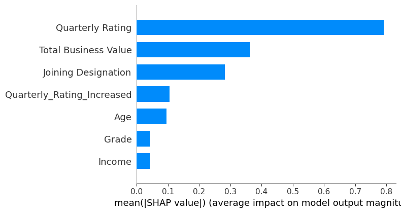

```python
shap.summary_plot(
    shap_values,
    X_val_sample,
    plot_type="bar",
    feature_names=feature_names
)
```

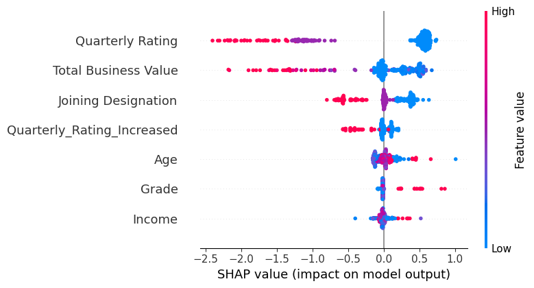

```python
shap.summary_plot(
    shap_values,
    X_val_sample,
    feature_names=feature_names
)
```

```python
mean_abs_shap = np.abs(shap_values).mean(axis=0)

importance_df = (
    pd.DataFrame({
        "Feature": feature_names,
        "MeanAbsSHAP": mean_abs_shap
    })
    .sort_values("MeanAbsSHAP", ascending=False)
    .reset_index(drop=True)
)

print(importance_df)
```

```
                      Feature  MeanAbsSHAP
0            Quarterly Rating     0.790650
1        Total Business Value     0.363237
2         Joining Designation     0.282037
3  Quarterly_Rating_Increased     0.105378
4                         Age     0.095511
5                       Grade     0.043770
6                      Income     0.042792
```

# ✅ Final Summary

## Model Selection

- After evaluting the models Random forest, XGBoost, Logistic regression, Light GBM and GBDT. The GBDT model performs well based on the following reasons.

### 1. Highest Recall (0.935)

- Recall is the most important metric here because:
  - We want to catch as many potential churn cases as possible.
  - Missing a churner is costlier than a false alarm.
- The GBDT model correctly identifies 93.5% of churn drivers, the best among all models.

### 2. Strong F1-score (0.886)

- F1 combines precision and recall.
- A high F1 means:
  - Model catches most churners (high recall)
  - Predictions are reasonably accurate (good precision)

### 3. Stable validation performance

- The validation metrics were close to testing metrics → low variance → model generalizes well.

## Final Conclusion

- The GBDT model is the best-performing and most reliable model for this problem.
- Its high recall (0.935) ensures that will catch most potential churners.
- SHAP provides strong explainability, helping the business team take targeted actions.
- With insights from SHAP, Ola can implement meaningful operational improvements:
  - Rating system upgrades
  - Incentive restructuring
  - Personalized retention efforts